# Exercício 10

Considere o seguinte experimento: 48 gerentes do sexo masculino receberam um currículo para julgar se o(a) candidato(a) deveria ser provido(a) ou não. Os currículos dos candidatos eram todos idênticos, exceto que metade indicava que o candidato era homem e metade indicava que era mulher. Os 48 gerentes receberam um CV cada, de maneira aleatória.

A tabela a seguir apresenta o resultado do experimento:

| Gênero/Decisão | promovido | não promovido | Total |
| --- | --- | --- | --- |
| homem | 21 | 3 | 24 |
| mulher | 14 | 10 | 24 |
| Total | 35 | 13 | 48 |

1. Estatísticos são muitas vezes requisitados para avaliar a força de uma evidência. Ao observar as taxas de promoção para homens e mulheres no estudo, por que poderíamos ser tentados a concluir imediatamente que as mulheres estão sofrendo discriminação?

A diferença na proporção de promovidos entre homens e entre mulheres é 0.29.

O tamanho amostral do estudo é pequeno, portanto esta alta diferença observada entre as proporções de promoção de homens e mulheres pode ter ocorrido ao acaso.

Temos duas hipóteses:

- $H_0$: Hipótese Nula. Gênero e decisão quanto à promoção são independentes. Não há relação entre as duas coisas e a diferença observada entre as proporções de promoção de homens e mulheres ocorreu ao acaso.
- $H_1$: Hipótese Alternativa. Gênero e decisão quanto à promoção não são independentes. A diferença observada entre as proporções de promoção de homens e mulheres não ocorreu ao acaso, pois mulheres sofreram discriminação.
2. O que significa, com relação à atitude dos gerentes, dizer que a hipótese nula é verdadeira?
3. O que significa, com relação à atitude dos gerentes, dizer que a hipótese alternativa é verdadeira?

Devemos decidir, baseando-se nos dados, se temos evidências ou não para rejeitar a hipótese nula.

Iremos simular várias repetições do experimento descrito, mas assumindo que a hipótese nula é verdadeira. O código a seguir produz a simulação:

```r
B <- 10000
CVs <- 1:48

mulheres <- 1:24
homens <- 25:48

Dif <- matrix(NA,ncol=1,nrow=B)
for (i in 1:B)
  {
  CVsAleatorizados <- sample(CVs,length(CVs), replace=FALSE)
  promovidos <- CVsAleatorizados[1:35]
  naopromovidos <- CVsAleatorizados[36:48]
  ProporcaoHomensPromovidos <- mean(homens %in% promovidos)
  ProporcaoMulheresPromovidas <- mean(mulheres %in% promovidos)
  Dif[i] <- ProporcaoHomensPromovidos-ProporcaoMulheresPromovidas
}
```

O histograma a seguir apresenta a distribuição de todas as diferenças observadas entre as proporções de promoção de homens e mulheres nas simulações. A linha vertical vermelha indica a diferença observada no experimento original.

Descreva a distribuição. Qual seu valor central aproximado? O valor central da dsitribuição das diferenças simuladas é condizente com a hipótese nula? Discuta.

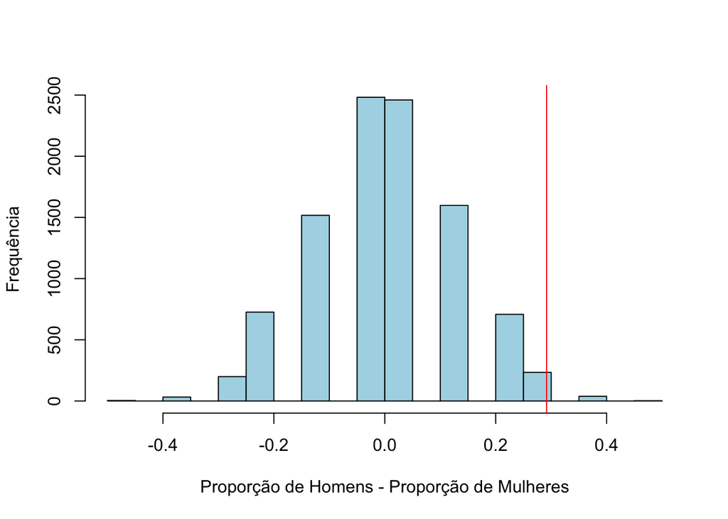

4. A diferença observada no experimento ocorrido foi 0.29. Você acredita é plausível que ele tenha ocorrido simplesmente ao acaso, se a hipótese nula é verdadeira? Discuta.

Dentre as diferenças simuladas, apenas 0.4% delas é superior à diferença observada no experimento original.